# P5_02_2_code_analyse

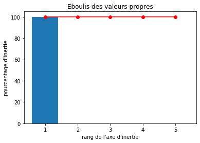

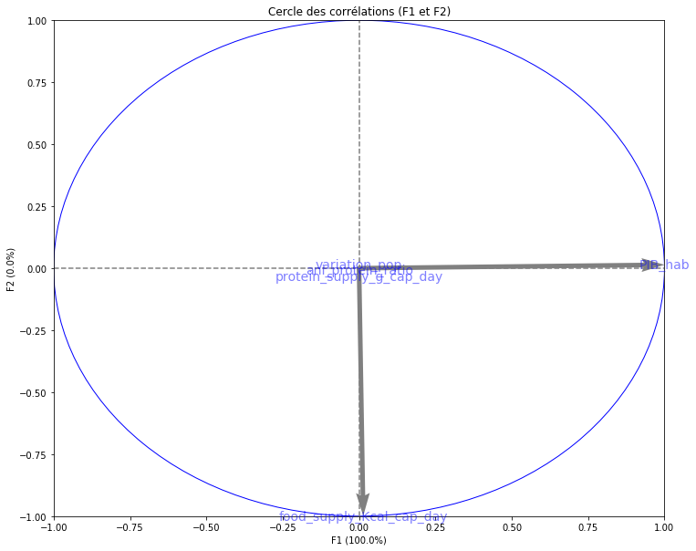

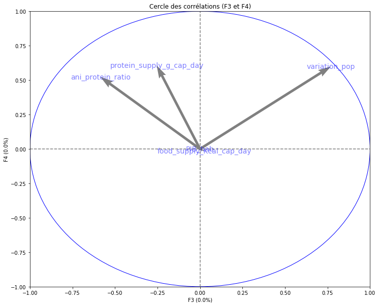

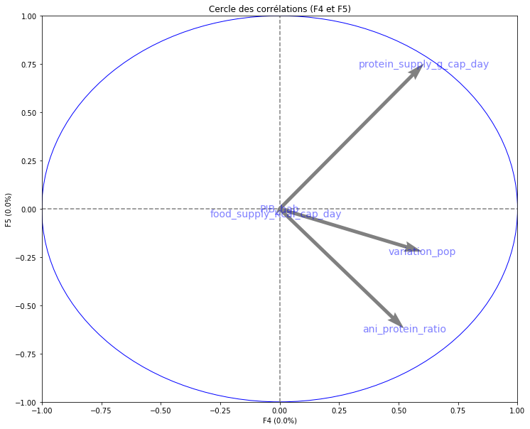

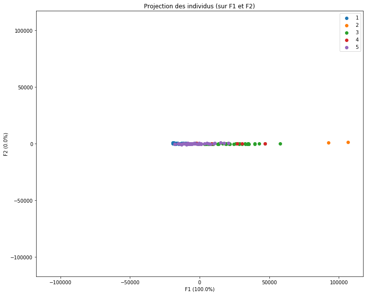

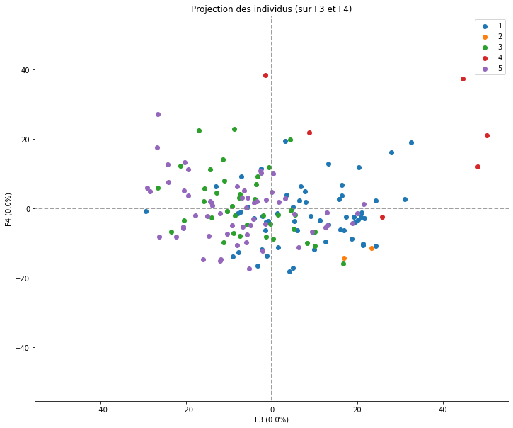

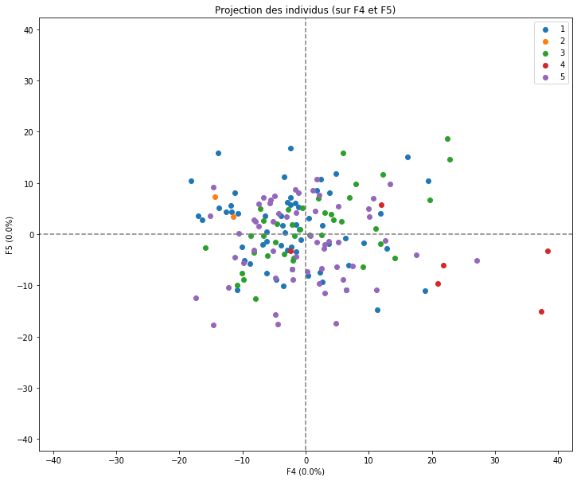

```python
# ACP et nuage des individus

# choix du nombre de composantes à calculer
n_comp = 5

selected_variables = ["variation_pop","food_supply_Kcal_cap_day","protein_supply_g_cap_day", "ani_protein_ratio",
                     "PIB_hab"]
X = data[selected_variables].values

# préparation des données pour l'ACP
names = data.index
features = selected_variables

# Centrage et Réduction
std_scale = preprocessing.StandardScaler().fit(X)
X_scaled = (X)

# Calcul des composantes principales
pca = decomposition.PCA(n_components=n_comp)
pca.fit(X_scaled)

# Eboulis des valeurs propres
display_scree_plot(pca)

# Cercle des corrélations
pcs = pca.components_
display_circles(pcs, n_comp, pca, [(0,1),(2,3),(3,4)], labels = np.array(features))

# Projection des individus
X_projected = pca.transform(X_scaled)
display_factorial_planes(X_projected, n_comp, pca, [(0,1),(2,3),(3,4)], illustrative_var = data.cluster)

plt.show()
```

L'analyse avec 5 clusters n'est pas pertinente au regard du dendrogramme : en effet à une distance de 10 on observe 4 groupes, soit moins que les 5 recommandés dans l'énoncé, et à une distance de 5 on en observe 10 : on prendra donc ces 10 groupes pour plus de précision.

```python
# Nouveau tableau des centroïdes avec 8 clusters

# Création d'une nouvelle colonne "cluster"
t = 10
clusters = fcluster(Z, t, criterion='maxclust')
data.drop(columns={"cluster"}, inplace=True)
data['cluster'] = clusters

# Tableau des centroïdes
centroides = data.groupby('cluster').mean()
centroides
```

| cluster | variation_pop | food_supply_Kcal_cap_day | protein_supply_g_cap_day | ani_protein_ratio | PIB_hab |
| --- | --- | --- | --- | --- | --- |
| 1 | 16.962761 | 2522.523810 | 65.075238 | 33.283892 | 6969.700000 |
| 2 | 35.261057 | 2727.733333 | 68.625333 | 23.347250 | 4834.686667 |
| 3 | 29.144995 | 2200.260870 | 54.294783 | 22.657842 | 2613.286957 |
| 4 | 24.019293 | 3166.500000 | 103.080000 | 65.267451 | 119870.500000 |
| 5 | -0.022407 | 3310.235294 | 101.587647 | 56.856032 | 29612.929412 |
| 6 | 7.588535 | 3477.272727 | 111.458182 | 61.419791 | 51631.481818 |
| 7 | 51.855353 | 2971.000000 | 90.073333 | 48.229714 | 37904.483333 |
| 8 | 16.127218 | 3288.375000 | 93.800000 | 28.761657 | 13041.725000 |
| 9 | 8.898041 | 2500.222222 | 76.392222 | 62.252705 | 25834.700000 |
| 10 | 7.072088 | 2941.024390 | 82.253902 | 46.781334 | 14444.246341 |

```python
# Création du deuxième fichier csv : coordonnées des centroides dans leurs dimensions

# Centrage/réduction
centroides_coordonnees = std_scale.transform(centroides)

# Ajout du nom des colonnes
centroides_coordonnees = pd.DataFrame(centroides_coordonnees)
colonnes = centroides.columns
centroides_coordonnees.columns= colonnes
centroides_coordonnees

# Exportation en csv
centroides_coordonnees.to_csv("fichier_csv2", index=False)
```

```python
# Affichage des pays contenus dans chaque cluster
for i in range(1,t+1):
    print("groupe {}".format(i))
    print(", ".join(data.country[data.cluster==i]))
```

[output not shown]

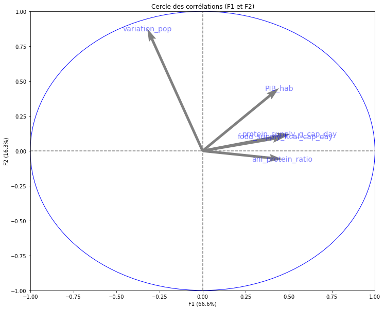

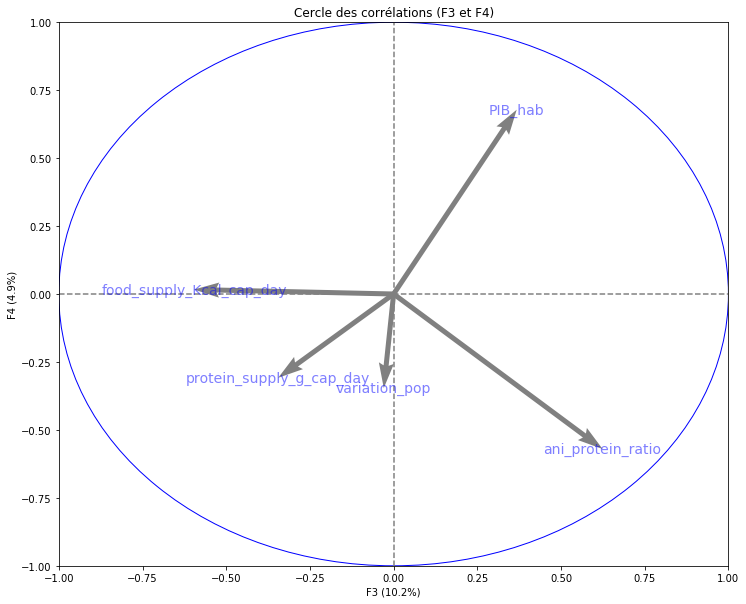

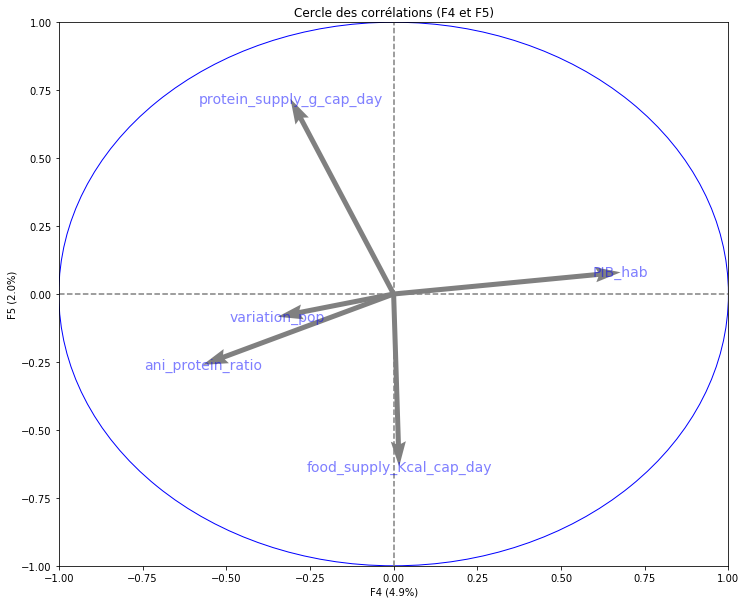

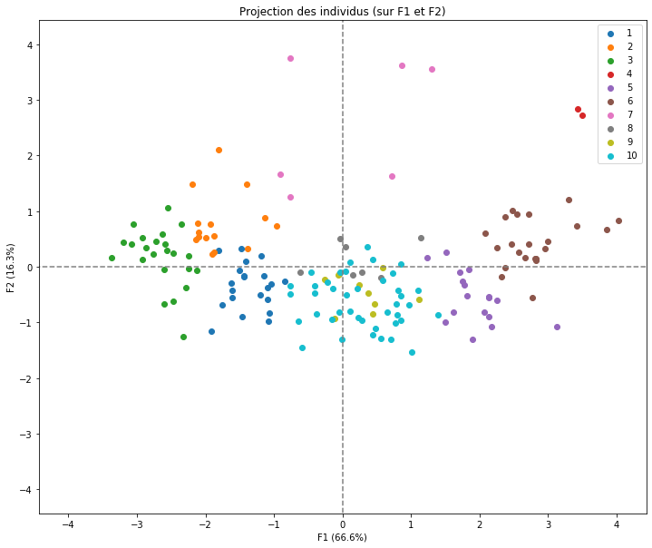

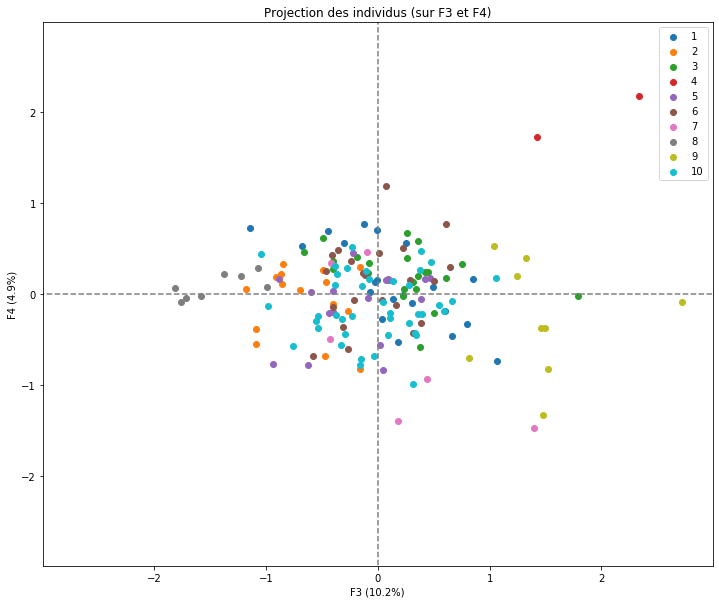

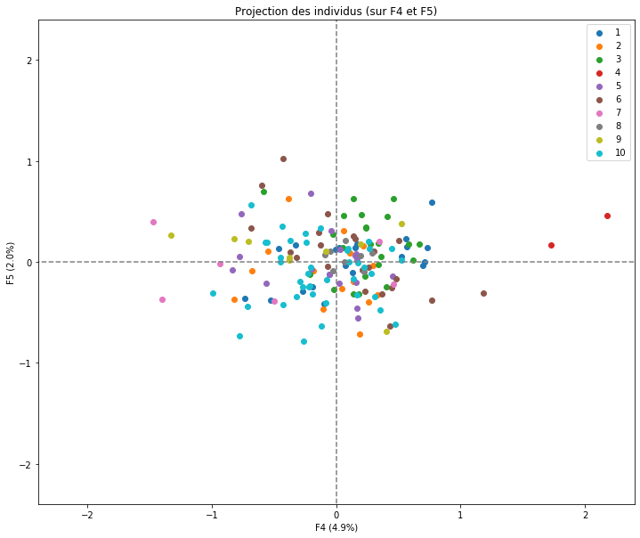

```python
# Nouvelle ACP et nouveau nuage des individus

# choix du nombre de composantes à calculer
n_comp = 5

X = data[selected_variables].values

# préparation des données pour l'ACP
names = data.index
features = selected_variables

# Centrage et Réduction
std_scale = preprocessing.StandardScaler().fit(X)
X_scaled = std_scale.transform(X)

# Calcul des composantes principales
pca = decomposition.PCA(n_components=n_comp)
pca.fit(X_scaled)

# Cercle des corrélations
pcs = pca.components_
display_circles(pcs, n_comp, pca, [(0,1),(2,3),(3,4)], labels = np.array(features))

# Projection des individus
X_projected = pca.transform(X_scaled)
display_factorial_planes(X_projected, n_comp, pca, [(0,1),(2,3),(3,4)], illustrative_var = data.cluster)

plt.show()
```

L'essentiel de l'information se trouve sur le premier plan factoriel (F1/F2), et j'arrive à isoler les indiv les uns des autres avec F1/F2. L'information des cinq variables a été résumée dans ces deux variables F1/F2.